# Mert Erdinc BADS Final Assignment

## Importing the data and uploading the necessary libraries

```python
import pandas as pd
import numpy as np
import matplotlib.pyplot as plt
# Some configuration of the plots we will create later
%matplotlib inline
plt.rcParams["figure.figsize"] = (12,6)
```

```python
dfk = pd.read_csv(r'C:\Users\Administrator\Desktop\BADS_WS2021_known.csv')
dfu = pd.read_csv(r'C:\Users\Administrator\Desktop\BADS_WS2021_unknown.csv')
```

## The outline

### Data Preparation & Explanatory Analysis

- Taking a look in the data
- Preparing Variables (Time data & Item size)
- Adjusting the Data types
- Explanatory Analysis
- Data Partioning
- Outlier and Missing handling
- Scalization & Normalization
- Feature Selection (Filter methods)
- Weight-of-Evidence coding the known & the unknown data sets
- Forward Regression & Backward Selection methods

  ### Model Building
- Logistic Regression
- Decision Trees
- Regularization
- Greedy Search Method & Cross Validation
- Random Forest
- Extreme Boosting Algorithm

  ### Cost Sensitive Analysis

  ### Getting the unknown data predictions

Note: Why Clustering won't be done?

- In the known data we have already two clusters as 0 and 1s. In the unknown data, we don't have that but since the aim is to decide whether a customer is going to return a product or not (1 and 0), trying to group individuals according to similarities with respect to each other is something that is not needed. A kind of multi-dimensional scaling map could be done as an explanatory analysis but because of the data set's size being big, it is also not practical to do.

## Data Preparation & Explanatory Analysis

### Taking a look in the data

```python
dfk  #in order to get a first feeling of the data and to see the columns etc. There are some missing values, time data and categorical variables
```

|  | order_item_id | order_date | delivery_date | item_id | item_size | item_color | brand_id | item_price | user_id | user_title | user_dob | user_state | user_reg_date | return |
| --- | --- | --- | --- | --- | --- | --- | --- | --- | --- | --- | --- | --- | --- | --- |
| 0 | 1 | 2016-06-22 | 2016-06-27 | 643 | 38 | navy | 30 | 49.90 | 30822 | Mrs | 1969-04-17 | Saxony | 2016-06-23 | 0 |
| 1 | 2 | 2016-06-22 | NaN | 337 | 152 | grey | 30 | 19.95 | 30822 | Mrs | 1969-04-17 | Saxony | 2016-06-23 | 0 |
| 2 | 3 | 2016-06-22 | 2016-06-27 | 270 | xxl | grey | 49 | 79.90 | 30823 | Mrs | 1970-04-22 | Baden-Wuerttemberg | 2015-03-15 | 1 |
| 3 | 4 | 2016-06-22 | 2016-06-27 | 142 | xxl | grey | 49 | 99.90 | 30823 | Mrs | 1970-04-22 | Baden-Wuerttemberg | 2015-03-15 | 0 |
| 4 | 5 | 2016-06-22 | 2016-06-27 | 561 | xxl | grey | 3 | 14.90 | 30823 | Mrs | 1970-04-22 | Baden-Wuerttemberg | 2015-03-15 | 1 |
| ... | ... | ... | ... | ... | ... | ... | ... | ... | ... | ... | ... | ... | ... | ... |
| 99995 | 99996 | 2016-09-11 | 2016-09-12 | 156 | 20 | blue | 34 | 29.90 | 713 | Mrs | 1959-03-21 | Rhineland-Palatinate | 2015-02-17 | 0 |
| 99996 | 99997 | 2016-09-11 | 2016-09-12 | 156 | 20 | brown | 34 | 29.90 | 713 | Mrs | 1959-03-21 | Rhineland-Palatinate | 2015-02-17 | 0 |
| 99997 | 99998 | 2016-09-11 | 1994-12-31 | 1832 | xxl | black | 37 | 26.90 | 47794 | Mr | 1985-03-01 | Hamburg | 2016-09-10 | 0 |
| 99998 | 99999 | 2016-09-11 | 1994-12-31 | 1832 | xxl | black | 37 | 26.90 | 47794 | Mr | 1985-03-01 | Hamburg | 2016-09-10 | 0 |
| 99999 | 100000 | 2016-09-11 | 2016-10-08 | 1891 | 28 | fuchsia | 47 | 27.90 | 2622 | Mrs | 1973-10-17 | Lower Saxony | 2015-02-17 | 0 |

100000 rows × 14 columns

```python
dfk.info()  #object data types needs to be fixed
```

```
<class 'pandas.core.frame.DataFrame'>
RangeIndex: 100000 entries, 0 to 99999
Data columns (total 14 columns):
 #   Column         Non-Null Count   Dtype
---  ------         --------------   -----
 0   order_item_id  100000 non-null  int64
 1   order_date     100000 non-null  object
 2   delivery_date  90682 non-null   object
 3   item_id        100000 non-null  int64
 4   item_size      100000 non-null  object
 5   item_color     100000 non-null  object
 6   brand_id       100000 non-null  int64
 7   item_price     100000 non-null  float64
 8   user_id        100000 non-null  int64
 9   user_title     100000 non-null  object
 10  user_dob       91275 non-null   object
 11  user_state     100000 non-null  object
 12  user_reg_date  100000 non-null  object
 13  return         100000 non-null  int64
dtypes: float64(1), int64(5), object(8)
memory usage: 10.7+ MB
```

```python
dfu
```

|  | order_item_id | order_date | delivery_date | item_id | item_size | item_color | brand_id | item_price | user_id | user_title | user_dob | user_state | user_reg_date |
| --- | --- | --- | --- | --- | --- | --- | --- | --- | --- | --- | --- | --- | --- |
| 0 | 100001 | 2016-10-15 | 2017-01-10 | 1591 | 40 | anthracite | 9 | 69.9 | 56943 | Mrs | 1967-09-18 | Baden-Wuerttemberg | 2016-10-16 |
| 1 | 100002 | 2016-10-15 | 2017-01-10 | 1589 | m | red | 11 | 69.9 | 56943 | Mrs | 1967-09-18 | Baden-Wuerttemberg | 2016-10-16 |
| 2 | 100003 | 2016-10-15 | 2017-01-10 | 1589 | s | red | 11 | 69.9 | 56943 | Mrs | 1967-09-18 | Baden-Wuerttemberg | 2016-10-16 |
| 3 | 100004 | 2016-10-15 | 2017-01-10 | 1776 | unsized | berry | 41 | 49.9 | 56943 | Mrs | 1967-09-18 | Baden-Wuerttemberg | 2016-10-16 |
| 4 | 100005 | 2016-10-15 | 2017-01-10 | 2140 | unsized | grey | 102 | 59.9 | 56943 | Mrs | 1967-09-18 | Baden-Wuerttemberg | 2016-10-16 |
| ... | ... | ... | ... | ... | ... | ... | ... | ... | ... | ... | ... | ... | ... |
| 49995 | 149996 | 2016-12-12 | 2016-12-13 | 1669 | 42 | brown | 43 | 89.9 | 48001 | Mrs | NaN | Lower Saxony | 2015-02-17 |
| 49996 | 149997 | 2016-12-12 | 2016-12-13 | 1409 | L | ash | 3 | 16.9 | 48001 | Mrs | NaN | Lower Saxony | 2015-02-17 |
| 49997 | 149998 | 2016-12-12 | 2016-12-13 | 114 | 42 | brown | 43 | 79.9 | 48001 | Mrs | NaN | Lower Saxony | 2015-02-17 |
| 49998 | 149999 | 2016-12-12 | 2016-12-13 | 1409 | XL | ash | 3 | 16.9 | 48001 | Mrs | NaN | Lower Saxony | 2015-02-17 |
| 49999 | 150000 | 2016-12-12 | 2016-12-13 | 1421 | XL | brown | 87 | 79.9 | 23651 | Mrs | 1967-10-26 | North Rhine-Westphalia | 2015-02-17 |

50000 rows × 13 columns

```python
dfk.shape, dfu.shape
```

```
((100000, 14), (50000, 13))
```

```python
dfu_order_item_id = dfu['order_item_id'] #will be used when the dfu predictions are being indexed at the end.


dfk.drop(['order_item_id', 'user_id'], axis=1, inplace=True)
dfu.drop(['order_item_id', 'user_id'], axis=1, inplace=True)
```

#### The ID numbers are dropped above because of the following reasons:

- Some users can be more prone to return the items than the others but keeping the user id column would only help to detect the likelihood of the same user returning an item and since this wouldn't help predicting the behavior of new users, this variable is excluded. Also dummy or WoE encoding over 10,000 users probably won't give us good results.
- Since Order id functions as just a counter it doesn't convey any meaningful information.

### Time Data Fixation

- In order for us to be able to use the variables that are related to time later in the prediction algorithms, they need to be converted to a number.
- The reason why they are being converted before the actual data exploratory phase is to be able to analyze them too.

#### User age

```python
from datetime import timedelta
dfk.user_dob = pd.to_datetime(dfk['user_dob'], format='%Y-%m-%d')

dfu.user_dob = pd.to_datetime(dfu['user_dob'], format='%Y-%m-%d')

dfk.user_dob
```

```
0       1969-04-17
1       1969-04-17
2       1970-04-22
3       1970-04-22
4       1970-04-22
           ...
99995   1959-03-21
99996   1959-03-21
99997   1985-03-01
99998   1985-03-01
99999   1973-10-17
Name: user_dob, Length: 100000, dtype: datetime64[ns]
```

```python
now = pd.Timestamp('now')
dfk['user_dob'] = dfk['user_dob'].where(dfk['user_dob'] < now, dfk['user_dob'] -  np.timedelta64(100, 'Y'))
dfk['user_age'] = (now - dfk['user_dob']).astype('<m8[Y]')

dfu['user_dob'] = dfu['user_dob'].where(dfu['user_dob'] < now, dfu['user_dob'] -  np.timedelta64(100, 'Y'))
dfu['user_age'] = (now - dfu['user_dob']).astype('<m8[Y]')

dfu.user_age        #as the difference in months and days wouldn't really be helpful in explaining the return behavior and since
                    #if an item is returned and age plays a role in it, it would be more likely because of the generational
                    # differences such as 5, 10, 20 years but not small differences like 0.1 or 0.2 and etc. Because of that
                    #user age is tought to be fine when it is calculated in years and not months or days.
```

```
0        53.0
1        53.0
2        53.0
3        53.0
4        53.0
         ...
49995     NaN
49996     NaN
49997     NaN
49998     NaN
49999    53.0
Name: user_age, Length: 50000, dtype: float64
```

#### Registration Date

```python
dfk.user_reg_date = pd.to_datetime(dfk['user_reg_date'], format='%Y-%m-%d')

dfu.user_reg_date = pd.to_datetime(dfu['user_reg_date'], format='%Y-%m-%d')
dfk.user_reg_date
```

```
0       2016-06-23
1       2016-06-23
2       2015-03-15
3       2015-03-15
4       2015-03-15
           ...
99995   2015-02-17
99996   2015-02-17
99997   2016-09-10
99998   2016-09-10
99999   2015-02-17
Name: user_reg_date, Length: 100000, dtype: datetime64[ns]
```

```python
dfk['user_reg_date'] = dfk['user_reg_date'].where(dfk['user_reg_date'] < now, dfk['user_reg_date'] -  np.timedelta64(1, 'M'))
dfk['user_reg_time'] = (now - dfk['user_reg_date']).astype('timedelta64[M]')

dfu['user_reg_date'] = dfu['user_reg_date'].where(dfu['user_reg_date'] < now, dfu['user_reg_date'] -  np.timedelta64(1, 'M'))
dfu['user_reg_time'] = (now - dfu['user_reg_date']).astype('timedelta64[M]')

dfu.user_reg_time               #Assuming that this variable is "User Registration Date", it is converted to time data type.
                    #It is converted to months because it wouldn't make much sense to assume that this variable's accuracy will
    #have the same amount of importance as delivery or order date variables, which will be calculated in days. Thus,
    #it doesn't need to be as precise as them nor as general as user age.
```

```
0        53.0
1        53.0
2        53.0
3        53.0
4        53.0
         ...
49995    73.0
49996    73.0
49997    73.0
49998    73.0
49999    73.0
Name: user_reg_time, Length: 50000, dtype: float64
```

#### Order date

```python
dfk.order_date = pd.to_datetime(dfk['order_date'], format='%Y-%m-%d') #conversion of data types in both known and unknown data sets
dfu.order_date = pd.to_datetime(dfu['order_date'], format='%Y-%m-%d')

dfk.order_date
```

```
0       2016-06-22
1       2016-06-22
2       2016-06-22
3       2016-06-22
4       2016-06-22
           ...
99995   2016-09-11
99996   2016-09-11
99997   2016-09-11
99998   2016-09-11
99999   2016-09-11
Name: order_date, Length: 100000, dtype: datetime64[ns]
```

```python
dfk['order_date'] = dfk['order_date'].where(dfk['order_date'] < now, dfk['order_date'] -  np.timedelta64(1, 'D'))
dfk['order_day'] = (now - dfk['order_date']).astype('timedelta64[D]')

dfu['order_date'] = dfu['order_date'].where(dfu['order_date'] < now, dfu['order_date'] -  np.timedelta64(1, 'D'))
dfu['order_day'] = (now - dfu['order_date']).astype('timedelta64[D]')

dfk.order_day   #This variable was converted in days because in the shipping sector, punctuality is something that most of the
               #consumers value. If we knew whether the specific store we are analyzing is offering a fast track delivery
               #(in one day for example), to increase precision, we could convert order date variable in hours or even minutes.
```

```
0        1759.0
1        1759.0
2        1759.0
3        1759.0
4        1759.0
          ...
99995    1678.0
99996    1678.0
99997    1678.0
99998    1678.0
99999    1678.0
Name: order_day, Length: 100000, dtype: float64
```

#### Delivery date

```python
dfk.delivery_date = pd.to_datetime(dfk['delivery_date'], format='%Y-%m-%d') #conversion of the data type in both data sets
dfu.delivery_date = pd.to_datetime(dfu['delivery_date'], format='%Y-%m-%d')

dfk.delivery_date
```

```
0       2016-06-27
1              NaT
2       2016-06-27
3       2016-06-27
4       2016-06-27
           ...
99995   2016-09-12
99996   2016-09-12
99997   1994-12-31
99998   1994-12-31
99999   2016-10-08
Name: delivery_date, Length: 100000, dtype: datetime64[ns]
```

```python
dfk=dfk[dfk.delivery_date != ('1994-12-31')]    #omitted 1072 rows.
```

- These values are obvious to be a system error. If the delivery date could not been tracked by the online retailer, the system might be filling those values automatically to a date such as the installation date of the tracking system or the like.
- We do not know yet whether delivery date variable will turnout to be predictive and worth keeping. Rather than omitting them one could calculate the average delivery duration and then impute these values with "order date + average delivery duration" however this might affect the decision whether to keep the variable or not also since the data set we have is big enough, we simply delete these rows.

```python
dfk['delivery_date'] = dfk['delivery_date'].where(dfk['delivery_date'] < now, dfk['delivery_date'] -  np.timedelta64(1, 'D'))
dfk['delivery_day'] = (now - dfk['delivery_date']).astype('timedelta64[D]')

dfu['delivery_date'] = dfu['delivery_date'].where(dfu['delivery_date'] < now, dfu['delivery_date'] -  np.timedelta64(1, 'D'))
dfu['delivery_day'] = (now - dfu['delivery_date']).astype('timedelta64[D]')

dfu.delivery_day
```

```
0        1557.0
1        1557.0
2        1557.0
3        1557.0
4        1557.0
          ...
49995    1585.0
49996    1585.0
49997    1585.0
49998    1585.0
49999    1585.0
Name: delivery_day, Length: 50000, dtype: float64
```

```python
max =dfu.delivery_day.max()
max
```

```
9603.0
```

```python
dfu.delivery_day.replace(dfu.delivery_day.max(), 0, inplace=True) #we put 0 instead of the day correspondence of '1994-12-31'
         #'1994-12-31' values are not omitted in the unknown data as we need an prediction for every order.
```

```python
dfu[dfu.delivery_day == dfu.delivery_day.max()] #check that it worked.
#or it can be checked by the following code also: dfu[dfu.delivery_date == ('1994-12-31')]
```

|  | order_date | delivery_date | item_id | item_size | item_color | brand_id | item_price | user_title | user_dob | user_state | user_reg_date | user_age | user_reg_time | order_day | delivery_day |
| --- | --- | --- | --- | --- | --- | --- | --- | --- | --- | --- | --- | --- | --- | --- | --- |
| 8 | 2016-10-15 | 2016-10-16 | 1749 | 42 | black | 43 | 99.90 | Mrs | 1964-06-14 | Lower Saxony | 2016-05-30 | 56.0 | 58.0 | 1644.0 | 1643.0 |
| 9 | 2016-10-15 | 2016-10-16 | 1630 | xxl | white | 37 | 49.90 | Mrs | 1964-06-14 | Lower Saxony | 2016-05-30 | 56.0 | 58.0 | 1644.0 | 1643.0 |
| 10 | 2016-10-15 | 2016-10-16 | 2246 | unsized | stained | 20 | 19.90 | Mrs | 1964-06-14 | Lower Saxony | 2016-05-30 | 56.0 | 58.0 | 1644.0 | 1643.0 |
| 16 | 2016-10-15 | 2016-10-16 | 1484 | 37 | black | 1 | 149.90 | Mrs | 1956-02-28 | Brandenburg | 2016-04-08 | 65.0 | 60.0 | 1644.0 | 1643.0 |
| 17 | 2016-10-15 | 2016-10-16 | 1889 | 37 | black | 55 | 239.90 | Mrs | 1956-02-28 | Brandenburg | 2016-04-08 | 65.0 | 60.0 | 1644.0 | 1643.0 |
| ... | ... | ... | ... | ... | ... | ... | ... | ... | ... | ... | ... | ... | ... | ... | ... |
| 615 | 2016-10-16 | 2016-10-16 | 1902 | 42 | ancient | 15 | 69.95 | Mrs | 1972-08-13 | Lower Saxony | 2015-02-17 | 48.0 | 73.0 | 1643.0 | 1643.0 |
| 616 | 2016-10-16 | 2016-10-16 | 1519 | unsized | ocher | 73 | 49.90 | Mrs | 1972-08-13 | Lower Saxony | 2015-02-17 | 48.0 | 73.0 | 1643.0 | 1643.0 |
| 617 | 2016-10-16 | 2016-10-16 | 1602 | unsized | brown | 73 | 69.90 | Mrs | 1972-08-13 | Lower Saxony | 2015-02-17 | 48.0 | 73.0 | 1643.0 | 1643.0 |
| 1284 | 2016-10-16 | 2016-10-16 | 1583 | 30 | red | 69 | 89.95 | Mrs | 1975-02-08 | Baden-Wuerttemberg | 2015-02-17 | 46.0 | 73.0 | 1643.0 | 1643.0 |
| 1285 | 2016-10-16 | 2016-10-16 | 1732 | 34 | brown | 69 | 109.95 | Mrs | 1975-02-08 | Baden-Wuerttemberg | 2015-02-17 | 46.0 | 73.0 | 1643.0 | 1643.0 |

91 rows × 15 columns

```python
print(dfu.delivery_day.isnull().sum().sum())
```

```
5845
```

```python
dfu.delivery_day.fillna(0, inplace=True) #this is done so that prediction algorithms can run on the unknown data
```

```python
print(dfu.delivery_day.isnull().sum().sum())
```

```
0
```

```python
print(dfk.delivery_date.isnull().sum().sum())
```

```
9318
```

**A finding:** Every NA value in the delivery date column has a return of 0, which makes it plausable to guess that the customers have not received the item they ordered yet for some reason. If the gap between the order date and the delivery date is too big, that could be accounted for a return behavior. So, because of this reason,our model needs a delivery date value and not NAs, which there is no way of predicting 100% correctly. Thus, they are excluded. Also, the if we don't exclude those values the model may predict a 0 whenever there is no delivery date, which is obviously not ideal and biased.

```python
dfk.delivery_date
```

```
0       2016-06-27
1              NaT
2       2016-06-27
3       2016-06-27
4       2016-06-27
           ...
99993   2016-09-13
99994   2016-09-13
99995   2016-09-12
99996   2016-09-12
99999   2016-10-08
Name: delivery_date, Length: 98928, dtype: datetime64[ns]
```

```python
mask = dfk['delivery_date'].isin(['NaT'])
dfk=dfk[~mask]
```

```python
dfk.delivery_date #comparing the lengths
```

```
0       2016-06-27
2       2016-06-27
3       2016-06-27
4       2016-06-27
5       2016-06-27
           ...
99993   2016-09-13
99994   2016-09-13
99995   2016-09-12
99996   2016-09-12
99999   2016-10-08
Name: delivery_date, Length: 89610, dtype: datetime64[ns]
```

```python
dfu['order_day'] = dfu['order_day'].mask(dfu.delivery_day == 0, 0) #this is done because otherwise in the next variable there would be wrong values (miscalculations)
```

```python
dfu[(dfu.delivery_day == 0)] #check
```

|  | order_date | delivery_date | item_id | item_size | item_color | brand_id | item_price | user_title | user_dob | user_state | user_reg_date | user_age | user_reg_time | order_day | delivery_day |
| --- | --- | --- | --- | --- | --- | --- | --- | --- | --- | --- | --- | --- | --- | --- | --- |
| 11 | 2016-10-15 | NaT | 1963 | xl | stained | 42 | 119.9 | Mr | 1940-05-14 | Baden-Wuerttemberg | 2015-02-17 | 80.0 | 73.0 | 0.0 | 0.0 |
| 94 | 2016-10-15 | NaT | 1916 | l | red | 42 | 99.9 | Mrs | 1966-03-06 | North Rhine-Westphalia | 2015-02-17 | 55.0 | 73.0 | 0.0 | 0.0 |
| 97 | 2016-10-15 | NaT | 1891 | 31 | pink | 47 | 29.9 | Mrs | 1974-08-29 | Rhineland-Palatinate | 2015-10-17 | 46.0 | 65.0 | 0.0 | 0.0 |
| 107 | 2016-10-15 | NaT | 1897 | xl | ocher | 31 | 79.9 | Mrs | 1961-03-28 | Hesse | 2016-06-02 | 60.0 | 58.0 | 0.0 | 0.0 |
| 108 | 2016-10-15 | NaT | 1598 | xl | mocca | 31 | 69.9 | Mrs | 1961-03-28 | Hesse | 2016-06-02 | 60.0 | 58.0 | 0.0 | 0.0 |
| ... | ... | ... | ... | ... | ... | ... | ... | ... | ... | ... | ... | ... | ... | ... | ... |
| 49934 | 2016-12-12 | 1994-12-31 | 2333 | M | grey | 37 | 59.9 | Mrs | 1962-11-21 | Lower Saxony | 2015-02-17 | 58.0 | 73.0 | 0.0 | 0.0 |
| 49951 | 2016-12-12 | NaT | 1858 | unsized | green | 73 | 24.9 | Mrs | 1968-02-19 | Baden-Wuerttemberg | 2015-08-22 | 53.0 | 67.0 | 0.0 | 0.0 |
| 49990 | 2016-12-12 | NaT | 1417 | L | black | 30 | 23.9 | Mrs | 1989-11-12 | Lower Saxony | 2016-12-06 | 31.0 | 52.0 | 0.0 | 0.0 |
| 49991 | 2016-12-12 | NaT | 1417 | m | black | 30 | 23.9 | Mrs | 1989-11-12 | Lower Saxony | 2016-12-06 | 31.0 | 52.0 | 0.0 | 0.0 |
| 49992 | 2016-12-12 | NaT | 1417 | m | black | 30 | 23.9 | Mrs | 1989-11-12 | Lower Saxony | 2016-12-06 | 31.0 | 52.0 | 0.0 | 0.0 |

6354 rows × 15 columns

#### Delivery Duration

```python
delivery_dur= (dfk.order_day - dfk.delivery_day)
dfk["delivery_dur"] = delivery_dur

delivery_dur= (dfu.order_day - dfu.delivery_day)
dfu["delivery_dur"] = delivery_dur

dfu.delivery_dur.describe() #the duration that the order took might be an important variable considering the domain knowledge.
                            #we also get some insights from the output of this function about the variable.
```

```
count    50000.000000
mean         7.868780
std         14.010645
min          0.000000
25%          1.000000
50%          3.000000
75%          5.000000
max        123.000000
Name: delivery_dur, dtype: float64
```

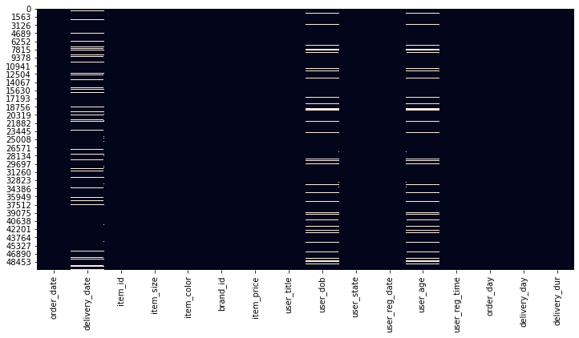

```python
import seaborn as sns
sns.heatmap(dfu.isnull(), cbar=False)  # quick visualization of the missing values in our data set

#User date of birth variable will be excluded, the missings in the user age variable will be imputed with the mean within the variable and delivery_date column will be omitted.
```

```python
print(dfu.user_dob.isnull().sum().sum())  #to get the exact numbers
print(dfu.user_age.isnull().sum().sum())
print(dfu.delivery_date.isnull().sum().sum())
print(dfu.delivery_day.isnull().sum().sum())
print(dfu.delivery_dur.isnull().sum().sum())
print(dfu.item_price.isnull().sum().sum())
```

```
5113
5113
5845
0
0
0
```

### Item size

**A remark:**

The online retailer is guessed to be mainly a clothing retail. The reason for that is that sizes as "s, m, l, xl" are clearly top sizes and they constitute more than half of the orders in total. Some other example evidences are the high likelihood of "3332, 3432, 3632, 3832, 4032" item sizes being pants sizes for adults. Another could be "104, 116, 128, 140, 152, 164, 176" item sizes likely being EU-converted pant sizes for children.

- Below the categorical and numerical item sizes are being seperated as the categorical ones needs to be encoded either with dummy or Weight-of-evidence method.
- Also, some of the reasons why item sizes are handled early in the notebook are to be able to analyze them in the data exploration section and the flexibility it provides for the next steps such as standardization, feature selection, encoding and the like.

```python
# Seperating each non-numeric categorical value of the item_size category

dfk_itemsize_10=dfk.loc[dfk['item_size'] == '10+']
dfk_itemsize_11=dfk.loc[dfk['item_size'] == '11+']
dfk_itemsize_12=dfk.loc[dfk['item_size'] == '12+']
dfk_itemsize_2=dfk.loc[dfk['item_size'] == '2+']
dfk_itemsize_3=dfk.loc[dfk['item_size'] == '3+']
dfk_itemsize_36=dfk.loc[dfk['item_size'] == '36+']
dfk_itemsize_37=dfk.loc[dfk['item_size'] == '37+']
dfk_itemsize_38=dfk.loc[dfk['item_size'] == '38+']
dfk_itemsize_39=dfk.loc[dfk['item_size'] == '39+']
dfk_itemsize_4=dfk.loc[dfk['item_size'] == '4+']
dfk_itemsize_40=dfk.loc[dfk['item_size'] == '40+']
dfk_itemsize_41=dfk.loc[dfk['item_size'] == '41+']
dfk_itemsize_42=dfk.loc[dfk['item_size'] == '42+']
dfk_itemsize_43=dfk.loc[dfk['item_size'] == '43+']
dfk_itemsize_44=dfk.loc[dfk['item_size'] == '44+']
dfk_itemsize_45=dfk.loc[dfk['item_size'] == '45+']
dfk_itemsize_46=dfk.loc[dfk['item_size'] == '46+']
dfk_itemsize_5=dfk.loc[dfk['item_size'] == '5+']
dfk_itemsize_6=dfk.loc[dfk['item_size'] == '6+']
dfk_itemsize_7=dfk.loc[dfk['item_size'] == '7+']
dfk_itemsize_8=dfk.loc[dfk['item_size'] == '8+']
dfk_itemsize_9=dfk.loc[dfk['item_size'] == '9+']
dfk_itemsize_l=dfk.loc[dfk['item_size'] == 'l']
dfk_itemsize_m=dfk.loc[dfk['item_size'] == 'm']
dfk_itemsize_s=dfk.loc[dfk['item_size'] == 's']
dfk_itemsize_unsized=dfk.loc[dfk['item_size'] == 'unsized'] # <- this item is assumed to be intangible product
dfk_itemsize_xl=dfk.loc[dfk['item_size'] == 'xl']            #such as some promotion code or something similar and thus kept.
dfk_itemsize_xs=dfk.loc[dfk['item_size'] == 'xs']
dfk_itemsize_xxl=dfk.loc[dfk['item_size'] == 'xxl']
dfk_itemsize_xxxl=dfk.loc[dfk['item_size'] == 'xxxl']
```

```python
#putting the values in one column together

frames = [dfk_itemsize_10['item_size'], dfk_itemsize_11['item_size'], dfk_itemsize_12['item_size'], dfk_itemsize_2['item_size'],
         dfk_itemsize_3['item_size'], dfk_itemsize_36['item_size'], dfk_itemsize_37['item_size'], dfk_itemsize_38['item_size'],
          dfk_itemsize_39['item_size'], dfk_itemsize_4['item_size'], dfk_itemsize_40['item_size'], dfk_itemsize_41['item_size'],
          dfk_itemsize_42['item_size'], dfk_itemsize_43['item_size'],dfk_itemsize_44['item_size'], dfk_itemsize_45['item_size'],
         dfk_itemsize_46['item_size'], dfk_itemsize_5['item_size'], dfk_itemsize_6['item_size'], dfk_itemsize_7['item_size'],
          dfk_itemsize_8['item_size'], dfk_itemsize_9['item_size'], dfk_itemsize_l['item_size'], dfk_itemsize_m['item_size'],
         dfk_itemsize_s['item_size'], dfk_itemsize_unsized['item_size'], dfk_itemsize_xl['item_size'], dfk_itemsize_xs['item_size'],
         dfk_itemsize_xxl['item_size'], dfk_itemsize_xxxl['item_size']]
item_size_cat = pd.concat(frames)
item_size_cat
```

```
1612      10+
1818      10+
1988      10+
2355      10+
3162      10+
         ...
87481    xxxl
91210    xxxl
94262    xxxl
98112    xxxl
98113    xxxl
Name: item_size, Length: 49349, dtype: object
```

```python
dfk['item_size_cat'] = item_size_cat   #including the column of non-numeric categorical variables of item_size to the dfk
dfk['item_size_cat']
```

```
0        NaN
2        xxl
3        xxl
4        xxl
5        xxl
        ...
99993    NaN
99994     xl
99995    NaN
99996    NaN
99999    NaN
Name: item_size_cat, Length: 89610, dtype: object
```

```python
dfk['item_size_cat'] = dfk['item_size_cat'].astype('category')
```

```python
dfk['item_size_cat'] = dfk['item_size_cat'].cat.add_categories('numeric')
dfk['item_size_cat'].fillna('numeric', inplace=True)     #added 'numeric' instead of NaNs.
dfk['item_size_cat']
```

```
0        numeric
2            xxl
3            xxl
4            xxl
5            xxl
          ...
99993    numeric
99994         xl
99995    numeric
99996    numeric
99999    numeric
Name: item_size_cat, Length: 89610, dtype: category
Categories (31, object): [10+, 11+, 12+, 2+, ..., xs, xxl, xxxl, numeric]
```

```python
#deleting the non-numerics of the item_size category

mask = dfk['item_size'].isin(['10+', '11+', '12+', '2+', '3+', '36+', '37+', '38+', '39+', '4+', '40+', '41+', '42+', '43+',
                             '44+', '45+', '46+', '5+', '6+', '7+', '8+', '9+', 'l', 'm', 's', 'unsized', 'xl', 'xs', 'xxl',
                             'xxxl'])
dfk['item_size_num'] = dfk['item_size'][~mask]
dfk['item_size_num']
```

```
0         38
2        NaN
3        NaN
4        NaN
5        NaN
        ...
99993     48
99994    NaN
99995     20
99996     20
99999     28
Name: item_size_num, Length: 89610, dtype: object
```

```python
dfk['item_size_num'] = dfk['item_size_num'].fillna('0')
print(dfk['item_size_num'])
print(dfk['item_size_cat'])  #NaNs are replaced by 0s
```

```
0        38
2         0
3         0
4         0
5         0
         ..
99993    48
99994     0
99995    20
99996    20
99999    28
Name: item_size_num, Length: 89610, dtype: object
0        numeric
2            xxl
3            xxl
4            xxl
5            xxl
          ...
99993    numeric
99994         xl
99995    numeric
99996    numeric
99999    numeric
Name: item_size_cat, Length: 89610, dtype: category
Categories (31, object): [10+, 11+, 12+, 2+, ..., xs, xxl, xxxl, numeric]
```

```python
dfk.drop(['item_size'], axis=1, inplace=True) #since the item size column were divided into two the original one can be excluded
```

```python
dfk  #confirming that it worked
```

|  | order_date | delivery_date | item_id | item_color | brand_id | item_price | user_title | user_dob | user_state | user_reg_date | return | user_age | user_reg_time | order_day | delivery_day | delivery_dur | item_size_cat | item_size_num |
| --- | --- | --- | --- | --- | --- | --- | --- | --- | --- | --- | --- | --- | --- | --- | --- | --- | --- | --- |
| 0 | 2016-06-22 | 2016-06-27 | 643 | navy | 30 | 49.9 | Mrs | 1969-04-17 | Saxony | 2016-06-23 | 0 | 51.0 | 57.0 | 1759.0 | 1754.0 | 5.0 | numeric | 38 |
| 2 | 2016-06-22 | 2016-06-27 | 270 | grey | 49 | 79.9 | Mrs | 1970-04-22 | Baden-Wuerttemberg | 2015-03-15 | 1 | 50.0 | 73.0 | 1759.0 | 1754.0 | 5.0 | xxl | 0 |
| 3 | 2016-06-22 | 2016-06-27 | 142 | grey | 49 | 99.9 | Mrs | 1970-04-22 | Baden-Wuerttemberg | 2015-03-15 | 0 | 50.0 | 73.0 | 1759.0 | 1754.0 | 5.0 | xxl | 0 |
| 4 | 2016-06-22 | 2016-06-27 | 561 | grey | 3 | 14.9 | Mrs | 1970-04-22 | Baden-Wuerttemberg | 2015-03-15 | 1 | 50.0 | 73.0 | 1759.0 | 1754.0 | 5.0 | xxl | 0 |
| 5 | 2016-06-22 | 2016-06-27 | 579 | grey | 3 | 19.9 | Mrs | 1970-04-22 | Baden-Wuerttemberg | 2015-03-15 | 1 | 50.0 | 73.0 | 1759.0 | 1754.0 | 5.0 | xxl | 0 |
| ... | ... | ... | ... | ... | ... | ... | ... | ... | ... | ... | ... | ... | ... | ... | ... | ... | ... | ... |
| 99993 | 2016-09-11 | 2016-09-13 | 1681 | anthracite | 9 | 69.9 | Mrs | 1958-04-24 | Baden-Wuerttemberg | 2015-02-17 | 1 | 62.0 | 73.0 | 1678.0 | 1676.0 | 2.0 | numeric | 48 |
| 99994 | 2016-09-11 | 2016-09-13 | 1600 | green | 75 | 219.9 | Mrs | 1958-04-24 | Baden-Wuerttemberg | 2015-02-17 | 0 | 62.0 | 73.0 | 1678.0 | 1676.0 | 2.0 | xl | 0 |
| 99995 | 2016-09-11 | 2016-09-12 | 156 | blue | 34 | 29.9 | Mrs | 1959-03-21 | Rhineland-Palatinate | 2015-02-17 | 0 | 62.0 | 73.0 | 1678.0 | 1677.0 | 1.0 | numeric | 20 |
| 99996 | 2016-09-11 | 2016-09-12 | 156 | brown | 34 | 29.9 | Mrs | 1959-03-21 | Rhineland-Palatinate | 2015-02-17 | 0 | 62.0 | 73.0 | 1678.0 | 1677.0 | 1.0 | numeric | 20 |
| 99999 | 2016-09-11 | 2016-10-08 | 1891 | fuchsia | 47 | 27.9 | Mrs | 1973-10-17 | Lower Saxony | 2015-02-17 | 0 | 47.0 | 73.0 | 1678.0 | 1651.0 | 27.0 | numeric | 28 |

89610 rows × 18 columns

The same procedure will be carried out for the unknown data as well.

```python
dfu.loc[:, 'item_size'] = dfu.item_size.replace("XS", "xs") #There are some item sizes that are essentially the same but typed
dfu.loc[:, 'item_size'] = dfu.item_size.replace("S", "s")   #differently. These values are fixed here
dfu.loc[:, 'item_size'] = dfu.item_size.replace("M", "m")
dfu.loc[:, 'item_size'] = dfu.item_size.replace("L", "l")
dfu.loc[:, 'item_size'] = dfu.item_size.replace("XL", "xl")
dfu.loc[:, 'item_size'] = dfu.item_size.replace("XXL", "xxl")
dfu.loc[:, 'item_size'] = dfu.item_size.replace("XXXL", "xxxl")
```

```python
# Seperating each non-numeric categorical value of the item_size category

dfu_itemsize_10=dfu.loc[dfu['item_size'] == '10+']
dfu_itemsize_11=dfu.loc[dfu['item_size'] == '11+']
dfu_itemsize_12=dfu.loc[dfu['item_size'] == '12+']
dfu_itemsize_3=dfu.loc[dfu['item_size'] == '3+']
dfu_itemsize_36=dfu.loc[dfu['item_size'] == '36+']
dfu_itemsize_37=dfu.loc[dfu['item_size'] == '37+']
dfu_itemsize_38=dfu.loc[dfu['item_size'] == '38+']
dfu_itemsize_39=dfu.loc[dfu['item_size'] == '39+']
dfu_itemsize_4=dfu.loc[dfu['item_size'] == '4+']
dfu_itemsize_40=dfu.loc[dfu['item_size'] == '40+']
dfu_itemsize_41=dfu.loc[dfu['item_size'] == '41+']
dfu_itemsize_42=dfu.loc[dfu['item_size'] == '42+']
dfu_itemsize_43=dfu.loc[dfu['item_size'] == '43+']
dfu_itemsize_44=dfu.loc[dfu['item_size'] == '44+']
dfu_itemsize_45=dfu.loc[dfu['item_size'] == '45+']
dfu_itemsize_46=dfu.loc[dfu['item_size'] == '46+']
dfu_itemsize_5=dfu.loc[dfu['item_size'] == '5+']
dfu_itemsize_6=dfu.loc[dfu['item_size'] == '6+']
dfu_itemsize_7=dfu.loc[dfu['item_size'] == '7+']
dfu_itemsize_8=dfu.loc[dfu['item_size'] == '8+']
dfu_itemsize_9=dfu.loc[dfu['item_size'] == '9+']
dfu_itemsize_l=dfu.loc[dfu['item_size'] == 'l']
dfu_itemsize_m=dfu.loc[dfu['item_size'] == 'm']
dfu_itemsize_s=dfu.loc[dfu['item_size'] == 's']
dfu_itemsize_unsized=dfu.loc[dfu['item_size'] == 'unsized']
dfu_itemsize_xl=dfu.loc[dfu['item_size'] == 'xl']
dfu_itemsize_xs=dfu.loc[dfu['item_size'] == 'xs']
dfu_itemsize_xxl=dfu.loc[dfu['item_size'] == 'xxl']
dfu_itemsize_xxxl=dfu.loc[dfu['item_size'] == 'xxxl']
```

```python
#putting the values in one column together

frames = [dfu_itemsize_10['item_size'], dfu_itemsize_11['item_size'], dfu_itemsize_12['item_size'],
         dfu_itemsize_3['item_size'], dfu_itemsize_36['item_size'], dfu_itemsize_37['item_size'], dfu_itemsize_38['item_size'],
          dfu_itemsize_39['item_size'], dfu_itemsize_4['item_size'], dfu_itemsize_40['item_size'], dfu_itemsize_41['item_size'],
          dfu_itemsize_42['item_size'], dfu_itemsize_43['item_size'],dfu_itemsize_44['item_size'], dfu_itemsize_45['item_size'],
         dfu_itemsize_46['item_size'], dfu_itemsize_5['item_size'], dfu_itemsize_6['item_size'], dfu_itemsize_7['item_size'],
          dfu_itemsize_8['item_size'], dfu_itemsize_9['item_size'], dfu_itemsize_l['item_size'], dfu_itemsize_m['item_size'],
         dfu_itemsize_s['item_size'], dfu_itemsize_unsized['item_size'], dfu_itemsize_xl['item_size'], dfu_itemsize_xs['item_size'],
         dfu_itemsize_xxl['item_size'], dfu_itemsize_xxxl['item_size']]
item_size_cat = pd.concat(frames)
item_size_cat
```

```
406       10+
1218      10+
2309      10+
2723      10+
2899      10+
         ...
49479    xxxl
49480    xxxl
49481    xxxl
49587    xxxl
49803    xxxl
Name: item_size, Length: 28435, dtype: object
```

```python
dfu['item_size_cat'] = item_size_cat   #including the column of non-numeric categorical variables of item size to the dfu
dfu['item_size_cat']
```

```
0            NaN
1              m
2              s
3        unsized
4        unsized
          ...
49995        NaN
49996          l
49997        NaN
49998         xl
49999         xl
Name: item_size_cat, Length: 50000, dtype: object
```

```python
dfu['item_size_cat'] = dfu['item_size_cat'].astype('category')
```

```python
dfu['item_size_cat'] = dfu['item_size_cat'].cat.add_categories('numeric')
dfu['item_size_cat'].fillna('numeric', inplace=True)     #missing values are replaced with the writing 'numeric'
dfu['item_size_cat']
```

```
0        numeric
1              m
2              s
3        unsized
4        unsized
          ...
49995    numeric
49996          l
49997    numeric
49998         xl
49999         xl
Name: item_size_cat, Length: 50000, dtype: category
Categories (30, object): [10+, 11+, 12+, 3+, ..., xs, xxl, xxxl, numeric]
```

```python
#deleting the non-numerics of the item_size category

mask = dfu['item_size'].isin(['10+', '11+', '12+', '2+', '3+', '36+', '37+', '38+', '39+', '4+', '40+', '41+', '42+', '43+',
                             '44+', '45+', '46+', '5+', '6+', '7+', '8+', '9+', 'l', 'm', 's', 'unsized', 'xl', 'xs', 'xxl',
                             'xxxl'])

dfu['item_size_num'] = dfu['item_size'][~mask]   #numerical item sizes are seperated from the original item size column
dfu['item_size_num']


dfu['item_size_num'] = dfu['item_size_num'].fillna('0')
dfu['item_size_num']                #NaNs are replaced by 0s

dfu.drop(['item_size'], axis=1, inplace=True)
dfu #confirmation that it worked
```

|  | order_date | delivery_date | item_id | item_color | brand_id | item_price | user_title | user_dob | user_state | user_reg_date | user_age | user_reg_time | order_day | delivery_day | delivery_dur | item_size_cat | item_size_num |
| --- | --- | --- | --- | --- | --- | --- | --- | --- | --- | --- | --- | --- | --- | --- | --- | --- | --- |
| 0 | 2016-10-15 | 2017-01-10 | 1591 | anthracite | 9 | 69.9 | Mrs | 1967-09-18 | Baden-Wuerttemberg | 2016-10-16 | 53.0 | 53.0 | 1644.0 | 1557.0 | 87.0 | numeric | 40 |
| 1 | 2016-10-15 | 2017-01-10 | 1589 | red | 11 | 69.9 | Mrs | 1967-09-18 | Baden-Wuerttemberg | 2016-10-16 | 53.0 | 53.0 | 1644.0 | 1557.0 | 87.0 | m | 0 |
| 2 | 2016-10-15 | 2017-01-10 | 1589 | red | 11 | 69.9 | Mrs | 1967-09-18 | Baden-Wuerttemberg | 2016-10-16 | 53.0 | 53.0 | 1644.0 | 1557.0 | 87.0 | s | 0 |
| 3 | 2016-10-15 | 2017-01-10 | 1776 | berry | 41 | 49.9 | Mrs | 1967-09-18 | Baden-Wuerttemberg | 2016-10-16 | 53.0 | 53.0 | 1644.0 | 1557.0 | 87.0 | unsized | 0 |
| 4 | 2016-10-15 | 2017-01-10 | 2140 | grey | 102 | 59.9 | Mrs | 1967-09-18 | Baden-Wuerttemberg | 2016-10-16 | 53.0 | 53.0 | 1644.0 | 1557.0 | 87.0 | unsized | 0 |
| ... | ... | ... | ... | ... | ... | ... | ... | ... | ... | ... | ... | ... | ... | ... | ... | ... | ... |
| 49995 | 2016-12-12 | 2016-12-13 | 1669 | brown | 43 | 89.9 | Mrs | NaT | Lower Saxony | 2015-02-17 | NaN | 73.0 | 1586.0 | 1585.0 | 1.0 | numeric | 42 |
| 49996 | 2016-12-12 | 2016-12-13 | 1409 | ash | 3 | 16.9 | Mrs | NaT | Lower Saxony | 2015-02-17 | NaN | 73.0 | 1586.0 | 1585.0 | 1.0 | l | 0 |
| 49997 | 2016-12-12 | 2016-12-13 | 114 | brown | 43 | 79.9 | Mrs | NaT | Lower Saxony | 2015-02-17 | NaN | 73.0 | 1586.0 | 1585.0 | 1.0 | numeric | 42 |
| 49998 | 2016-12-12 | 2016-12-13 | 1409 | ash | 3 | 16.9 | Mrs | NaT | Lower Saxony | 2015-02-17 | NaN | 73.0 | 1586.0 | 1585.0 | 1.0 | xl | 0 |
| 49999 | 2016-12-12 | 2016-12-13 | 1421 | brown | 87 | 79.9 | Mrs | 1967-10-26 | North Rhine-Westphalia | 2015-02-17 | 53.0 | 73.0 | 1586.0 | 1585.0 | 1.0 | xl | 0 |

50000 rows × 17 columns

```python
print(dfu.user_age.isnull().sum().sum())
print(dfu.item_price.isnull().sum().sum())
print(dfu.user_reg_time.isnull().sum().sum())
print(dfu.order_day.isnull().sum().sum())
print(dfu.delivery_day.isnull().sum().sum())
print(dfu.delivery_dur.isnull().sum().sum())
```

```
5113
0
0
0
0
0
```

Missings from user age will be imputed later in the notebook.

### Data Type Adjustment

```python
dfk.info()  #checking the data types
```

```
<class 'pandas.core.frame.DataFrame'>
Int64Index: 89610 entries, 0 to 99999
Data columns (total 18 columns):
 #   Column         Non-Null Count  Dtype
---  ------         --------------  -----
 0   order_date     89610 non-null  datetime64[ns]
 1   delivery_date  89610 non-null  datetime64[ns]
 2   item_id        89610 non-null  int64
 3   item_color     89610 non-null  object
 4   brand_id       89610 non-null  int64
 5   item_price     89610 non-null  float64
 6   user_title     89610 non-null  object
 7   user_dob       81766 non-null  datetime64[ns]
 8   user_state     89610 non-null  object
 9   user_reg_date  89610 non-null  datetime64[ns]
 10  return         89610 non-null  int64
 11  user_age       81766 non-null  float64
 12  user_reg_time  89610 non-null  float64
 13  order_day      89610 non-null  float64
 14  delivery_day   89610 non-null  float64
 15  delivery_dur   89610 non-null  float64
 16  item_size_cat  89610 non-null  category
 17  item_size_num  89610 non-null  object
dtypes: category(1), datetime64[ns](4), float64(6), int64(3), object(4)
memory usage: 12.4+ MB
```

Having data type as object is not advantegous if we know what the data type of the variable should be because some libraries and functions only work with certain data types and object data type might not be aligned with those always

We will convert the data types that are more efficient and feasible so that our model can run.

```python
#The target variable has only two states where the product is either returned (1), or it is not returned (0)
#so that we can store it as the following.
dfk['return'] = dfk['return'].astype(int)
```

```python
dfk['item_id'] = dfk['item_id'].astype('category')  #all of these variables are essentially categorical variables
dfu['item_id'] = dfu['item_id'].astype('category')

dfu['brand_id'] = dfu['brand_id'].astype('category')
dfk['brand_id'] = dfk['brand_id'].astype('category')

dfk['item_color'] = dfk['item_color'].astype('category')
dfu['item_color'] = dfu['item_color'].astype('category')

dfk['user_title'] = dfk['user_title'].astype('category')
dfu['user_title'] = dfu['user_title'].astype('category')

dfk['user_state'] = dfk['user_state'].astype('category')
dfu['user_state'] = dfu['user_state'].astype('category')
```

```python
dfk['item_size_num'] = dfk['item_size_num'].astype('float32')
dfu['item_size_num'] = dfu['item_size_num'].astype('float32')
```

```python
#To reduce memory consumption
num_vars1 = dfk.select_dtypes(include=np.float64).columns
dfk[num_vars1] = dfk[num_vars1].astype(np.float32)

num_vars2 = dfk.select_dtypes(include=np.int64).columns
dfk[num_vars2] = dfk[num_vars2].astype(np.int32)


#Same with the unknown data
num_vars3 = dfu.select_dtypes(include=np.float64).columns
dfu[num_vars3] = dfu[num_vars3].astype(np.float32)

num_vars4 = dfu.select_dtypes(include=np.int64).columns
dfu[num_vars4] = dfu[num_vars4].astype(np.int32)
```

```python
dfk.info()
```

```
<class 'pandas.core.frame.DataFrame'>
Int64Index: 89610 entries, 0 to 99999
Data columns (total 18 columns):
 #   Column         Non-Null Count  Dtype
---  ------         --------------  -----
 0   order_date     89610 non-null  datetime64[ns]
 1   delivery_date  89610 non-null  datetime64[ns]
 2   item_id        89610 non-null  category
 3   item_color     89610 non-null  category
 4   brand_id       89610 non-null  category
 5   item_price     89610 non-null  float32
 6   user_title     89610 non-null  category
 7   user_dob       81766 non-null  datetime64[ns]
 8   user_state     89610 non-null  category
 9   user_reg_date  89610 non-null  datetime64[ns]
 10  return         89610 non-null  int32
 11  user_age       81766 non-null  float32
 12  user_reg_time  89610 non-null  float32
 13  order_day      89610 non-null  float32
 14  delivery_day   89610 non-null  float32
 15  delivery_dur   89610 non-null  float32
 16  item_size_cat  89610 non-null  category
 17  item_size_num  89610 non-null  float32
dtypes: category(6), datetime64[ns](4), float32(7), int32(1)
memory usage: 6.9 MB
```

```python
dfu.info()   #confirmatory checks
```

```
<class 'pandas.core.frame.DataFrame'>
RangeIndex: 50000 entries, 0 to 49999
Data columns (total 17 columns):
 #   Column         Non-Null Count  Dtype
---  ------         --------------  -----
 0   order_date     50000 non-null  datetime64[ns]
 1   delivery_date  44155 non-null  datetime64[ns]
 2   item_id        50000 non-null  category
 3   item_color     50000 non-null  category
 4   brand_id       50000 non-null  category
 5   item_price     50000 non-null  float32
 6   user_title     50000 non-null  category
 7   user_dob       44887 non-null  datetime64[ns]
 8   user_state     50000 non-null  category
 9   user_reg_date  50000 non-null  datetime64[ns]
 10  user_age       44887 non-null  float32
 11  user_reg_time  50000 non-null  float32
 12  order_day      50000 non-null  float32
 13  delivery_day   50000 non-null  float32
 14  delivery_dur   50000 non-null  float32
 15  item_size_cat  50000 non-null  category
 16  item_size_num  50000 non-null  float32
dtypes: category(6), datetime64[ns](4), float32(7)
memory usage: 3.3 MB
```

Date time type variables will be deleted below.

### Explanatory Analysis

**Some controversial missings:** Item color has values of "?" and user title "not reported". These are essentially missing values but since there is a chance of these variables turning out to be not predictive for the model, the rows who include these values won't be excluded for now.

```python
dfk.describe()
```

|  | item_price | return | user_age | user_reg_time | order_day | delivery_day | delivery_dur | item_size_num |
| --- | --- | --- | --- | --- | --- | --- | --- | --- |
| count | 89610.000000 | 89610.000000 | 81766.000000 | 89610.000000 | 89610.000000 | 89610.000000 | 89610.000000 | 89610.000000 |
| mean | 65.785965 | 0.506807 | 56.640865 | 64.957458 | 1719.821655 | 1712.319458 | 7.401685 | 20.962013 |
| std | 47.983963 | 0.499956 | 11.316482 | 7.183679 | 24.555536 | 28.814404 | 13.491859 | 115.129883 |
| min | 0.000000 | 0.000000 | 9.000000 | 55.000000 | 1678.000000 | 1543.000000 | 0.000000 | 0.000000 |
| 25% | 29.900000 | 0.000000 | 50.000000 | 57.000000 | 1699.000000 | 1692.000000 | 2.000000 | 0.000000 |
| 50% | 49.900002 | 1.000000 | 56.000000 | 65.000000 | 1715.000000 | 1712.000000 | 3.000000 | 0.000000 |
| 75% | 79.900002 | 1.000000 | 61.000000 | 73.000000 | 1747.000000 | 1734.000000 | 5.000000 | 39.000000 |
| max | 999.000000 | 1.000000 | 120.000000 | 73.000000 | 1759.000000 | 1755.000000 | 173.000000 | 4034.000000 |

With the table above, we can see some general information about the variables, Some of which will also be further elaborated on below.

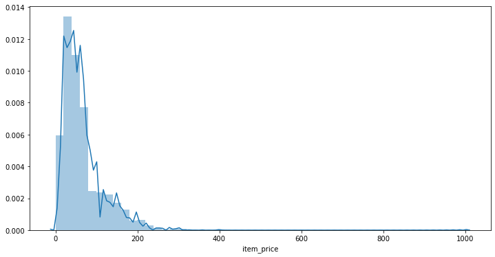

```python
sns.distplot(dfk['item_price']);
```

In this density plot of item prices, one can observe how the distribution of the item prices are. There might be evidence for some outliers. Also, since the distribution of low and mediocre priced items is higher than the more expensive items, this might indicate, the online retail positioning itself as low to middle segment. If the shape of this graph was inverted (symettrical to 100 €), meaning that there are less products that are cheap and more that are more expensive, we would have an evidence of the possible positioning and the strategy of the retail store.

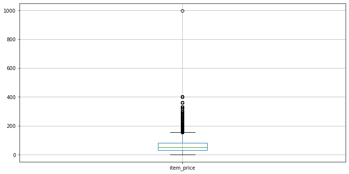

```python
dfk.boxplot(column = 'item_price') #as expected there are some outliers between the prices of 180 to 400 euros. There are
#also some extreme outliers around 1000 euros which needs handling and will be done in the next parts.
```

The return ratio is far from providing imbalanced classes. Thus, methods such as undersampling, oversampling or SMOTE won't be used.

```python
dfk.groupby("return").mean()   #insight in the delivery_dur column is counter-intuitive.
```

| return | item_price | user_age | user_reg_time | order_day | delivery_day | delivery_dur | item_size_num |
| --- | --- | --- | --- | --- | --- | --- | --- |
| 0 | 58.799229 | 57.117977 | 64.804596 | 1720.571533 | 1712.955688 | 7.615907 | 20.543386 |
| 1 | 72.497406 | 56.177830 | 65.106224 | 1719.562256 | 1712.369019 | 7.193218 | 21.369394 |

If the differences between the cases where the return is 0 and 1 was higher in more variables, this table could prove to be more useful. Since it is not, it wouldn't be safe to draw conclusions based on such small differences. However, item price variable shows a significant difference. That is, the mean of the items' prices that are returned is 23.30% higher than the ones that are kept. This is important as it can signal that this variable might be predictive of the return behavior to some extent.

```python
dfk.user_title.value_counts()
```

```
Mrs             85669
Mr               3398
Family            321
Company           127
not reported       95
Name: user_title, dtype: int64
```

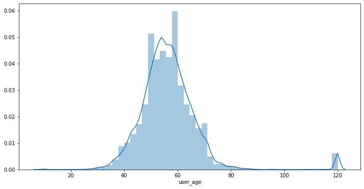

```python
sns.distplot(dfk['user_age']);  #similar to a normal distribution with some potential outliers
```

The distribution of the customers' ages resembles of a normal distribution, which is kind of typical with ages. Also, low in number but, we observe both relatively young and senior customers. One important point that needs to be paid attention to is the outliers around the age of 120. These values are open to discussion because it is not a very common age and will be handled in a more detailed way below.

```python
dfk.groupby(dfk['order_date'].dt.strftime('%B'))['return'].mean().sort_values()
```

```
order_date
June         0.491972
July         0.496434
September    0.499276
August       0.521034
Name: return, dtype: float64
```

During the summer season there is a small but steady increase in the return. If we compare the months of June and August, there is an increase from June to August but it is hard to derive a solid insight out of that and connect it to seasonality.

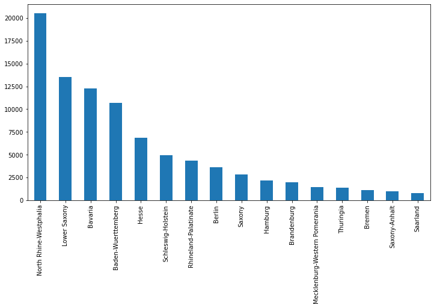

```python
dfk['user_state'].value_counts().plot(kind='bar');
```

```python
dfk[dfk.user_state == "North Rhine-Westphalia"]['return'].value_counts()
```

```
0    10363
1    10129
Name: return, dtype: int64
```

```python
dfk[dfk.user_state == "Lower Saxony"]['return'].value_counts()
```

```
1    6980
0    6571
Name: return, dtype: int64
```

```python
dfk[dfk.user_state == "Bavaria"]['return'].value_counts()
```

```
1    6343
0    5910
Name: return, dtype: int64
```

```python
dfk[dfk.user_state == "Baden-Wuerttemberg"]['return'].value_counts()
```

```
1    5408
0    5300
Name: return, dtype: int64
```

We don't find evidence of such an effect. Thus, because of the closeness of the distribution of 1's and 0's between states, this variable is also less likely to turn out as predictive.

```
array([[<matplotlib.axes._subplots.AxesSubplot object at 0x0000021C2727C6D0>]],
      dtype=object)
```

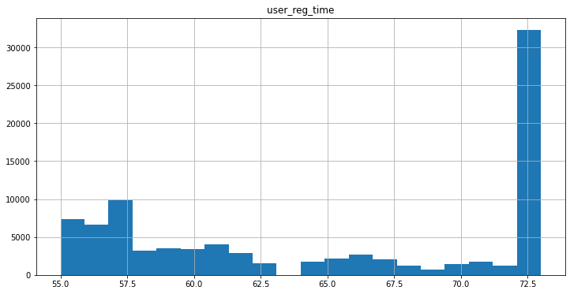

```python
# Histogram of user_reg_time values
dfk.hist(column = 'user_reg_time',
        bins   = 20)
```

By looking at the histogram above we see around one third of the customers who has shopped from the online retailer belong to the percentage of customers who have been registered to the online retailers system or website the longest.

```python
dfk[dfk.user_reg_time > 70]['return'].value_counts()
```

```
1    18390
0    16864
Name: return, dtype: int64
```

```python
dfk[dfk.user_reg_time < 70 ]['return'].value_counts()
```

```
0    26628
1    26285
Name: return, dtype: int64
```

One last possible insight is that people who registered to the system earlier may be slightly more likely to return a bought product since the data suggests so.

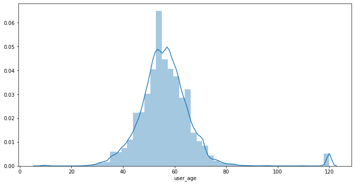

```python
sns.distplot(dfu['user_age']);   #similar distribution for the unknown data and some potential outliers.
```

The plot above is a small proof that both of the data sets share distributions that are similar to each other. This is also the case with the other variables. They also have outliers and missing values. Thus, all of the problematic values in both of the data sets needs fixation.

```python
print(dfu.user_age.isnull().sum().sum())
print(dfu.item_price.isnull().sum().sum())
print(dfu.user_reg_time.isnull().sum().sum())
print(dfu.order_day.isnull().sum().sum())
print(dfu.delivery_day.isnull().sum().sum())
print(dfu.delivery_dur.isnull().sum().sum())
```

```
5113
0
0
0
0
0
```

```python
dfk.drop(['order_date', 'delivery_date', 'user_dob', 'user_reg_date'], axis=1, inplace=True) #we drop the idle variables
dfu.drop(['order_date', 'delivery_date', 'user_dob', 'user_reg_date'], axis=1, inplace=True)
```

```python
#Before splitting the data, it is easier to fix some more typos now to avoid fixing data seperately in training and test sets:
dfk.loc[:, "item_color"] = dfk.item_color.replace("brwon", "brown")     #fixed the mistyped browns as "brwons"
dfk.loc[:, "item_color"] = dfk.item_color.replace("blau", "blue")     #fixed the blues
dfk = dfk[dfk.item_color != '?']  #There are some '?' values in the column item color. Since these mean that they are NaNs,
                                  #in other words missing values and since they cannot be imputed, they are removed.

dfu.loc[:, "item_color"] = dfu.item_color.replace("brwon", "brown")     #same for the unknown data
dfu.loc[:, "item_color"] = dfu.item_color.replace("blau", "blue")
#'?' values in the unknown data won't be removed so that we can make predictions about every order
```

### Data Partioning

In order to be able to assess our prediction model with a data set it has not seen before, replicating how our model would perform with the real unknown data, we split the data into two sets; namely, training and test data. For building the model training data will be used and for testing its performance the test data will be used and this will give more reliable and realistic results as the possibility of overfitting will be decreased.

```python
np.random.seed(888)
split_sample = np.random.rand(len(dfk)) < 0.7

dfk_train = dfk[split_sample]
dfk_test =  dfk[~split_sample]
```

**Note:** The return column is not splitted at the moment so that if any row has to be excluded it doesn't need to be excluded seperately. Also, data is partioned even before outlier and missing values handling because Interquantile range calculation (for truncation) and mean calculations (for imputation) will differ in the test and training set.

```python
dfk_train.describe()
```

|  | item_price | return | user_age | user_reg_time | order_day | delivery_day | delivery_dur | item_size_num |
| --- | --- | --- | --- | --- | --- | --- | --- | --- |
| count | 62565.000000 | 62565.000000 | 57188.000000 | 62565.000000 | 62565.000000 | 62565.000000 | 62565.000000 | 62565.000000 |
| mean | 65.928932 | 0.506705 | 56.625271 | 64.961975 | 1720.055054 | 1712.576904 | 7.365364 | 20.847151 |
| std | 48.131378 | 0.499959 | 11.255821 | 7.179719 | 24.521835 | 28.759979 | 13.446850 | 112.734596 |
| min | 0.000000 | 0.000000 | 9.000000 | 55.000000 | 1678.000000 | 1543.000000 | 0.000000 | 0.000000 |
| 25% | 29.900000 | 0.000000 | 50.000000 | 57.000000 | 1699.000000 | 1692.000000 | 2.000000 | 0.000000 |
| 50% | 49.900002 | 1.000000 | 56.000000 | 65.000000 | 1715.000000 | 1712.000000 | 3.000000 | 0.000000 |
| 75% | 79.900002 | 1.000000 | 61.000000 | 73.000000 | 1747.000000 | 1734.000000 | 5.000000 | 39.000000 |
| max | 999.000000 | 1.000000 | 120.000000 | 73.000000 | 1759.000000 | 1755.000000 | 173.000000 | 4032.000000 |

```python
dfk_test.describe()
```

|  | item_price | return | user_age | user_reg_time | order_day | delivery_day | delivery_dur | item_size_num |
| --- | --- | --- | --- | --- | --- | --- | --- | --- |
| count | 26987.000000 | 26987.000000 | 24523.000000 | 26987.000000 | 26987.000000 | 26987.000000 | 26987.000000 | 26987.000000 |
| mean | 65.474571 | 0.508022 | 56.680626 | 64.947014 | 1720.176392 | 1712.672607 | 7.458703 | 21.273354 |
| std | 47.637772 | 0.499945 | 11.462635 | 7.194823 | 24.637053 | 28.928720 | 13.597214 | 120.637642 |
| min | 0.000000 | 0.000000 | 9.000000 | 55.000000 | 1678.000000 | 1577.000000 | 0.000000 | 0.000000 |
| 25% | 31.950001 | 0.000000 | 50.000000 | 57.000000 | 1699.000000 | 1692.000000 | 2.000000 | 0.000000 |
| 50% | 49.900002 | 1.000000 | 56.000000 | 65.000000 | 1716.000000 | 1712.000000 | 3.000000 | 0.000000 |
| 75% | 79.900002 | 1.000000 | 62.000000 | 73.000000 | 1748.000000 | 1734.000000 | 5.000000 | 39.000000 |
| max | 399.950012 | 1.000000 | 120.000000 | 73.000000 | 1759.000000 | 1755.000000 | 135.000000 | 4034.000000 |

### Outlier Handling

There are some reasons why outliers are not desirable. Some of these can be listed as: Outliers in supervised learning algorithms can result in poorer outcomes, they are not representative of the data so they create bias and lastly, they manipulate statistical calculations in a negative way, which may affect some of the important decisions that will depend on those calculations.

The boxplots below show whether there are some outliers in the numeric values, to which extent they are far from other observations etc.

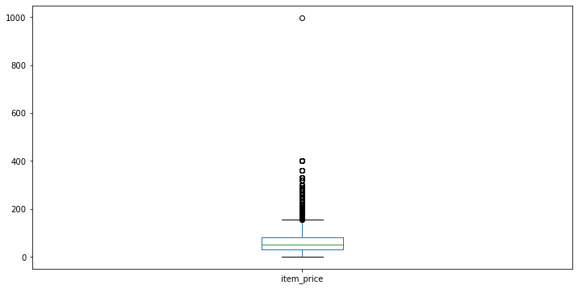

```python
dfk_train.item_price[:,].plot(kind = 'box', subplots=True);  #some outliers
```

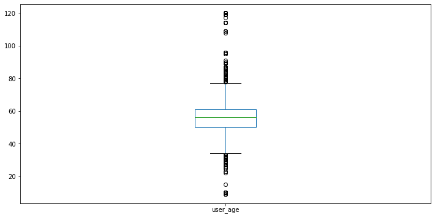

```python
dfk_train.user_age[:,].plot(kind = 'box', subplots=True);  #some outliers
```

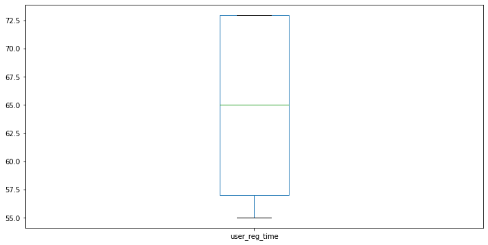

```python
dfk_train.user_reg_time[:,].plot(kind = 'box', subplots=True); #no outlier
```

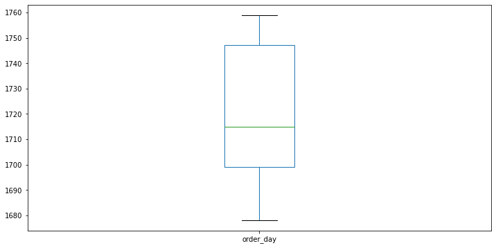

```python
dfk_train.order_day[:,].plot(kind = 'box', subplots=True);  #no outlier
```

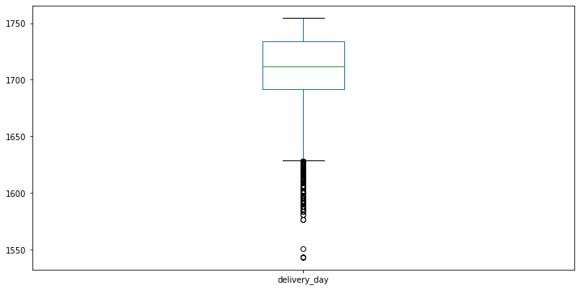

```python
dfk_train.delivery_day[:,].plot(kind = 'box', subplots=True);  #some outliers
```

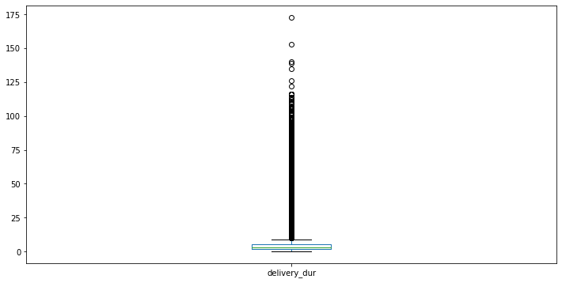

```python
dfk_train.delivery_dur[:,].plot(kind = 'box', subplots=True); #some outliers
```

There are many items that took quite some time to be delivered. These are outliers but since they are large in numbers and not some small number of exceptions they won't be truncated. The same way of thinking applies to the variable "delivery_day" too, which has a low chance to be predictive by only itself anyways.

```python
# Truncation function
def outlier_truncation(x, factor=1.5):

    # Calculate IQR
    IQR = x.quantile(0.75) - x.quantile(0.25)

    # Define upper/lower bound
    upper = x.quantile(0.75) + factor*IQR
    lower = x.quantile(0.25) - factor*IQR

    # Truncation
    x[x < lower] = lower
    x[x > upper] = upper


    return x
```

```python
dfk_train.item_price=outlier_truncation(dfk_train.item_price, factor=1.5)
dfk_train.item_price.describe()
```

```
count    62565.000000
mean        63.345600
std         40.454281
min          0.000000
25%         29.900000
50%         49.900002
75%         79.900002
max        154.900009
Name: item_price, dtype: float64
```

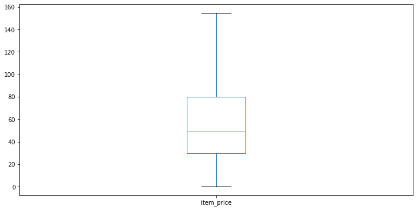

```python
dfk_train.item_price[:,].plot(kind = 'box', subplots=True);  #to confirm that outliers are truncated
```

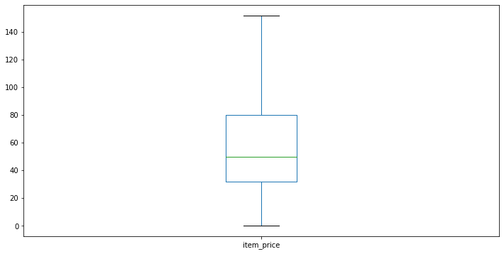

```python
dfk_test.item_price=outlier_truncation(dfk_test.item_price, factor=1.5) #test set item price
dfk_test.item_price[:,].plot(kind = 'box', subplots=True);
```

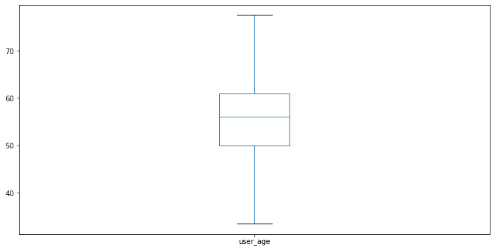

```python
dfk_train.user_age=outlier_truncation(dfk_train.user_age, factor=1.5)
dfk_train.user_age[:,].plot(kind = 'box', subplots=True);
```

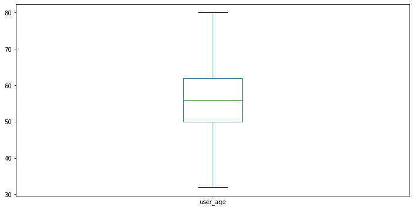

```python
dfk_test.user_age=outlier_truncation(dfk_test.user_age, factor=1.5)
dfk_test.user_age[:,].plot(kind = 'box', subplots=True);
```

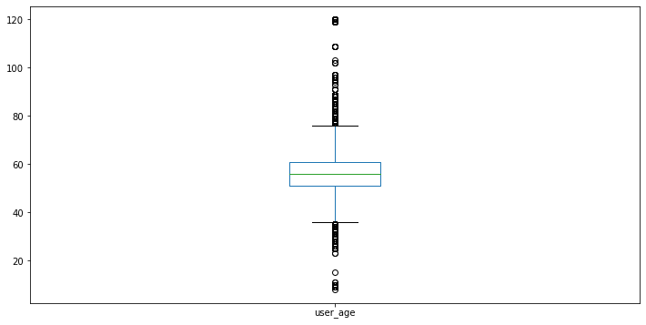

```python
dfu.user_age[:,].plot(kind = 'box', subplots=True);
```

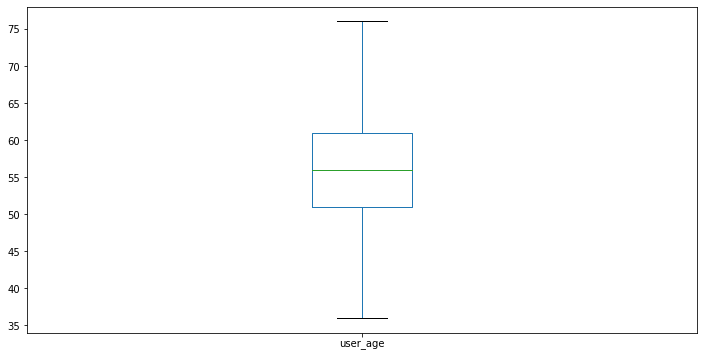

```python
dfu.user_age=outlier_truncation(dfu.user_age, factor=1.5)
dfu.user_age[:,].plot(kind = 'box', subplots=True);
```

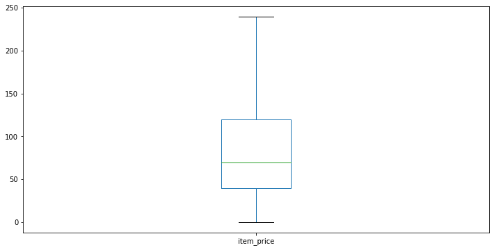

```python
dfu.item_price=outlier_truncation(dfu.item_price, factor=1.5)
dfu.item_price[:,].plot(kind = 'box', subplots=True);
```

So, using the IQR method the outliers in the variables user_age and item_price have been truncated in all of the data sets.

### Missing Values Mean Imputation

There are no missing values in the item price variable but there are some in the user age. The missing values in this variable will be replaced by the population mean and for the mean not to be affected by the outliers in the variable, this process is done after taking care of the outliers in the variable.

```python
print(dfu.user_age.isnull().sum().sum())
```

```
5113
```

```python
print(dfk_train.user_age.isnull().sum().sum())
print(dfk_test.user_age.isnull().sum().sum())
```

```
5377
2464
```

```python
print(dfk_train.user_age.mean()) #1st mean
```

```
56.04172134399414
```

```python
dfk_train_filtered_user_age = dfk_train['user_age'].dropna() #imputation with the mean is being done
dfk_train.user_age = dfk_train['user_age'].fillna(round(dfk_train_filtered_user_age.mean()))
```

```python
print(dfk_train.user_age.mean()) #2nd mean  #confirming that two means are different
```

```
56.03813552856445
```

```python
print(dfk_test.user_age.mean()) #1st mean  #same procedure for the test data set
```

```
56.1071662902832
```

```python
dfk_test_filtered_user_age = dfk_test['user_age'].dropna()
dfk_test.user_age = dfk_test['user_age'].fillna(round(dfk_test_filtered_user_age.mean()))
```

```python
print(dfk_test.user_age.mean()) #1st mean
```

```
56.097381591796875
```

```python
print(dfu.user_age.mean()) #1st mean  #same procedure for the unknown data set
```

```
55.9611701965332
```

```python
dfu_filtered_user_age = dfu['user_age'].dropna()
dfu.user_age = dfu['user_age'].fillna(round(dfu_filtered_user_age.mean()))
```

```python
print(dfu.user_age.mean()) #2nd mean   #change confirmed
```

```
55.96514129638672
```

```python
print(dfk_train.user_age.isnull().sum().sum())
print(dfk_test.user_age.isnull().sum().sum())
print(dfu.user_age.isnull().sum().sum())

print(dfu.user_reg_time.isnull().sum().sum())
print(dfu.order_day.isnull().sum().sum())
print(dfu.delivery_day.isnull().sum().sum())
print(dfu.delivery_dur.isnull().sum().sum())
```

```
0
0
0
0
0
0
0
```

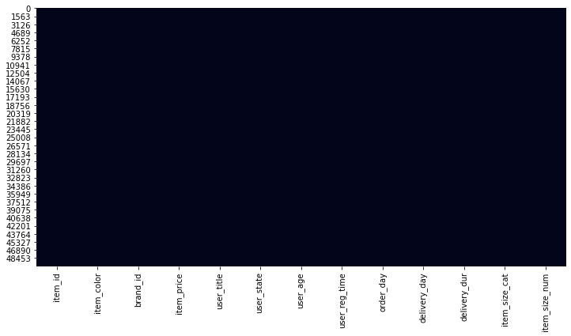

```python
sns.heatmap(dfu.isnull(), cbar=False)  # quick visualization of the missing values in our data set
```

```python
print(dfk_train.user_age.isnull().sum().sum())
print(dfk_train.user_reg_time.isnull().sum().sum())
print(dfk_train.order_day.isnull().sum().sum())
print(dfk_train.delivery_day.isnull().sum().sum())
print(dfk_train.delivery_dur.isnull().sum().sum())


print(dfk_test.user_age.isnull().sum().sum())
print(dfk_test.user_reg_time.isnull().sum().sum())
print(dfk_test.order_day.isnull().sum().sum())
print(dfk_test.delivery_day.isnull().sum().sum())
print(dfk_test.delivery_dur.isnull().sum().sum())
```

```
0
0
0
0
0
0
0
0
0
0
```

Now, all three data sets are free of any potentially problematic outliers or missing values.

## Scalization & Normalization

### Normalization

Assumption of normality is an aspect that plays an important role while crucial decisions are being made for the model. In some cases, it can also be of importance when doing descriptive or predictive modelling. Because of these reasons, it is useful to normalize the variables, which we will do below.

**Note:** Also, since we might need to scale the data after the normalization once more, scalization is done after normalization.

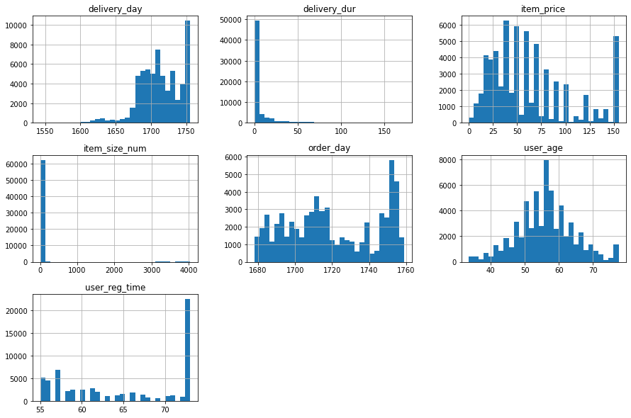

```python
dfk_train.select_dtypes(include='float32').hist(bins=30, figsize=(15, 10)); #Quick way to see which variables are likely to be normally distributed
```

Only user age is close to having a normal distribution.

Now we start normalization according to the order of histograms above.

**Note:** The normalization doesn't normalize the variables 100% percent but it normalizes them to some extent. Normalization of item price was quite distinct so it is normalized. In the preparation of this Notebook other variables were normalized too so that all of the variables are normalized a bit more and they are exposed to the same procedures (this is what I would do); however this lowered the AUC of the models. Also, the filter method table, which includes statistical calculations, was run when all of the variables were normalized and it gives the same results when they are not.

```python
dfk_train_copy = dfk_train.copy() #as a backup in case of errors below
dfk_test_copy = dfk_train.copy()
dfu_copy = dfu.copy()

dfk_train_copy2 = dfk_train.copy() #as a backup in case of errors below
dfk_test_copy2 = dfk_train.copy()
dfu_copy2 = dfu.copy()
```

#### Delivery day

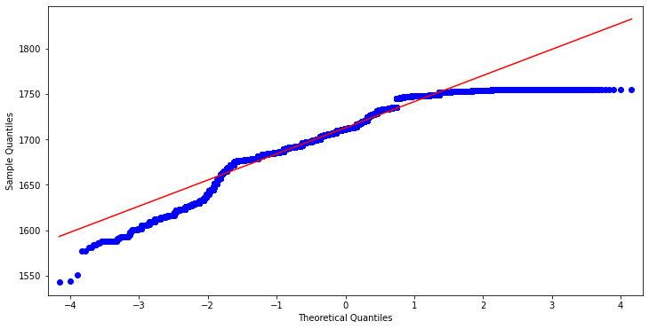

```python
from scipy import stats
from statsmodels.graphics.gofplots import qqplot #quantile-quantile plot
                                                 #the more the blue line matches with the red one, the likelier it becomes
qqplot(dfk_train.delivery_day, line='s')         #for that variable to follow a normal distribution
plt.show()                                       #we first check the untouched version of the variable.
```

When applying the Box Cox transformation, one needs to be careful about the 0 values as they cannot be used.

```python
dfk_train[dfk_train.delivery_day == 0] #No 0s
```

|  | item_id | item_color | brand_id | item_price | user_title | user_state | return | user_age | user_reg_time | order_day | delivery_day | delivery_dur | item_size_cat | item_size_num |
| --- | --- | --- | --- | --- | --- | --- | --- | --- | --- | --- | --- | --- | --- | --- |

```python
bc_fitted_feature, bc_fitted_lambda = stats.boxcox(dfk_train.delivery_day)

bc_fitted_lambda    #Using scipy functions we calculate the point where the normality is maximized, which is the fitted lambda
```

```
5.7674190473778415
```

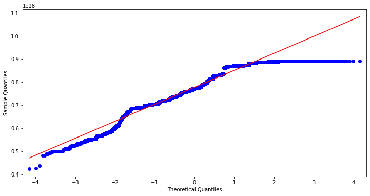

```python
qqplot(bc_fitted_feature, line='s')
plt.show()
```

```python
bc_fitted_feature.mean()
```

```
7.7737795e+17
```

```python
bc_fitted_feature
```

```
array([8.8857877e+17, 8.8857877e+17, 8.8857877e+17, ..., 6.8352955e+17,
       6.8352955e+17, 6.2677791e+17], dtype=float32)
```

When this variable is normalized it causes problems such as staying very large even after the scalization or giving some NaN values so because of that reason we are not going to normalize this variable and we are going to give up the slight improvement in the normalization suggested by the q-q plot. Because of the same reason order day variable won't be normalized as well.

#### Delivery duration

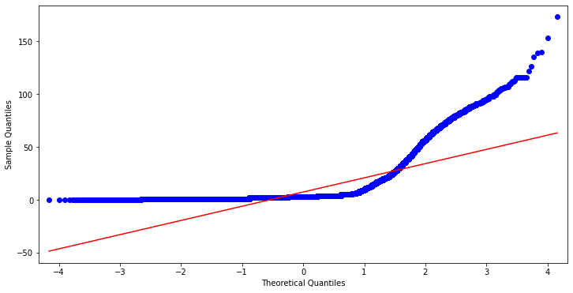

```python
qqplot(dfk_train.delivery_dur, line='s')
plt.show()
```

```python
bc_fitted_feature, bc_fitted_lambda = stats.boxcox(dfk_train.delivery_dur+1)
bc_fitted_lambda
#gives error without the +1
```

```
-0.6517853455761282
```

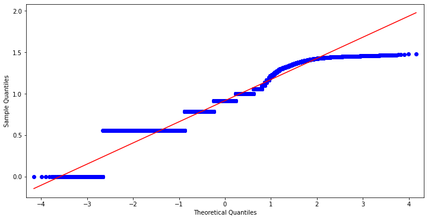

```python
qqplot(bc_fitted_feature, line='s')
plt.show()
```

```python
print(bc_fitted_feature)
print(bc_fitted_feature.mean())
print(dfk_train.delivery_dur.mean())
```

```
[1.0570393  1.0570393  1.0570393  ... 0.78450036 0.78450036 1.3594    ]
0.91637397
7.365364074707031
```

```python
print(stats.normaltest(dfk_train.delivery_dur))
print(stats.normaltest(bc_fitted_feature))       #seems like no difference in the normality statistically,
                                                 #but there is improvement in the graph
```

```
NormaltestResult(statistic=48704.19404083055, pvalue=0.0)
NormaltestResult(statistic=211.1435304401521, pvalue=1.4150276303448896e-46)
```

```python
bc_fitted_feature, bc_fitted_lambda = stats.boxcox(dfk_test.delivery_dur+1)
dfk_test.delivery_dur = bc_fitted_feature
```

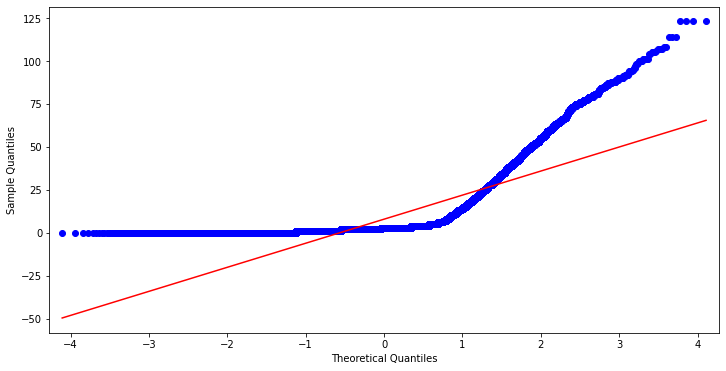

```python
qqplot(dfu.delivery_dur, line='s')
plt.show()
```

```python
bc_fitted_feature, bc_fitted_lambda = stats.boxcox(dfu.delivery_dur+1)
```

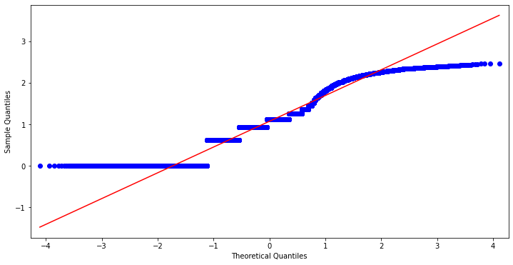

```python
qqplot(bc_fitted_feature, line='s')
plt.show()
```

#### Item price

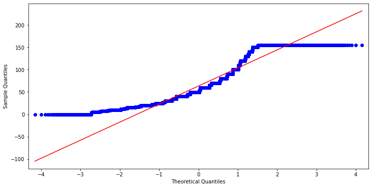

```python
qqplot(dfk_train.item_price, line='s')
plt.show()
```

```python
bc_fitted_feature, bc_fitted_lambda = stats.boxcox(dfk_train.item_price+1)
bc_fitted_lambda
```

```
0.2888641135822261
```

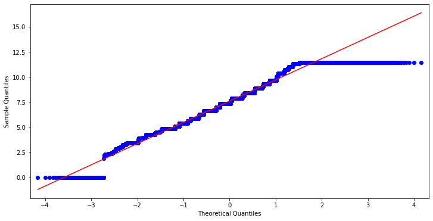

```python
qqplot(bc_fitted_feature, line='s')
plt.show()
```

```python
dfk_train.item_price = bc_fitted_feature #improvement is observed
```

```python
bc_fitted_feature1, bc_fitted_lambda1 = stats.boxcox(dfk_test.item_price+1)  #same operation for test data
dfk_test.item_price = bc_fitted_feature1
```

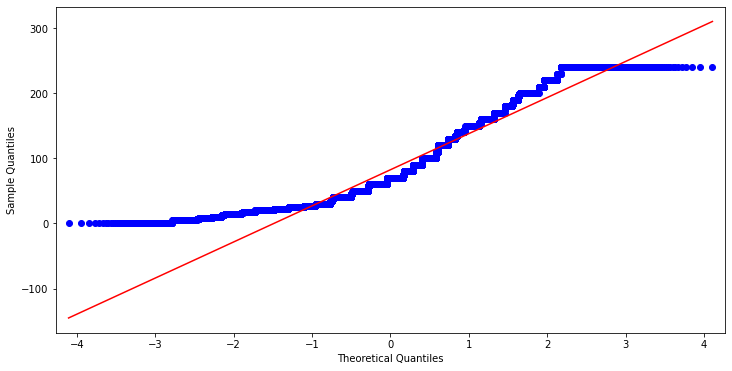

```python
qqplot(dfu.item_price, line='s')
plt.show()
```

```python
bc_fitted_feature, bc_fitted_lambda = stats.boxcox(dfu.item_price+1)
```

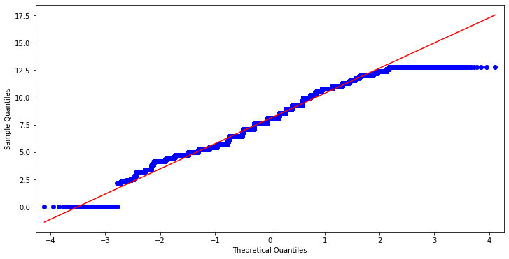

```python
qqplot(bc_fitted_feature, line='s') #a better plot
plt.show()
```

```python
dfu.item_price = bc_fitted_feature
```